# Cardio Good Fitness Project

### By: Swaraj Tripathy

## Structure of the Data

```python
# import relevant libraries

# data manipulation
import numpy as np
import pandas as pd

# data visualization
import matplotlib.pyplot as plt
import seaborn as sns
```

```python
# load in the dataset
raw_data = pd.read_csv("CardioGoodFitness.csv")
```

```python
# check if data loaded correctly
raw_data.head()
```

|  | Product | Age | Gender | Education | MaritalStatus | Usage | Fitness | Income | Miles |
| --- | --- | --- | --- | --- | --- | --- | --- | --- | --- |
| 0 | TM195 | 18 | Male | 14 | Single | 3 | 4 | 29562 | 112 |
| 1 | TM195 | 19 | Male | 15 | Single | 2 | 3 | 31836 | 75 |
| 2 | TM195 | 19 | Female | 14 | Partnered | 4 | 3 | 30699 | 66 |
| 3 | TM195 | 19 | Male | 12 | Single | 3 | 3 | 32973 | 85 |
| 4 | TM195 | 20 | Male | 13 | Partnered | 4 | 2 | 35247 | 47 |

```python
# create a copy of the data that can be manipulated
data = raw_data.copy()
```

```python
# the first 5 rows of the dataset
data.head()
```

|  | Product | Age | Gender | Education | MaritalStatus | Usage | Fitness | Income | Miles |
| --- | --- | --- | --- | --- | --- | --- | --- | --- | --- |
| 0 | TM195 | 18 | Male | 14 | Single | 3 | 4 | 29562 | 112 |
| 1 | TM195 | 19 | Male | 15 | Single | 2 | 3 | 31836 | 75 |
| 2 | TM195 | 19 | Female | 14 | Partnered | 4 | 3 | 30699 | 66 |
| 3 | TM195 | 19 | Male | 12 | Single | 3 | 3 | 32973 | 85 |
| 4 | TM195 | 20 | Male | 13 | Partnered | 4 | 2 | 35247 | 47 |

```python
# the last 5 rows of the dataset
data.tail()
```

|  | Product | Age | Gender | Education | MaritalStatus | Usage | Fitness | Income | Miles |
| --- | --- | --- | --- | --- | --- | --- | --- | --- | --- |
| 175 | TM798 | 40 | Male | 21 | Single | 6 | 5 | 83416 | 200 |
| 176 | TM798 | 42 | Male | 18 | Single | 5 | 4 | 89641 | 200 |
| 177 | TM798 | 45 | Male | 16 | Single | 5 | 5 | 90886 | 160 |
| 178 | TM798 | 47 | Male | 18 | Partnered | 4 | 5 | 104581 | 120 |
| 179 | TM798 | 48 | Male | 18 | Partnered | 4 | 5 | 95508 | 180 |

```python
# check for duplicate rows, displays total number of duplicate rows
data.duplicated().sum()
```

```
0
```

```python
# datatypes and null values in all columns
data.info()
```

```
<class 'pandas.core.frame.DataFrame'>
RangeIndex: 180 entries, 0 to 179
Data columns (total 9 columns):
 #   Column         Non-Null Count  Dtype
---  ------         --------------  -----
 0   Product        180 non-null    object
 1   Age            180 non-null    int64
 2   Gender         180 non-null    object
 3   Education      180 non-null    int64
 4   MaritalStatus  180 non-null    object
 5   Usage          180 non-null    int64
 6   Fitness        180 non-null    int64
 7   Income         180 non-null    int64
 8   Miles          180 non-null    int64
dtypes: int64(6), object(3)
memory usage: 12.8+ KB
```

There are 6 numerical variables and 3 categorical variables. No columns have missing values

```python
# numerical summary of numerical columns
data.describe().T
```

|  | count | mean | std | min | 25% | 50% | 75% | max |
| --- | --- | --- | --- | --- | --- | --- | --- | --- |
| Age | 180.0 | 28.788889 | 6.943498 | 18.0 | 24.00 | 26.0 | 33.00 | 50.0 |
| Education | 180.0 | 15.572222 | 1.617055 | 12.0 | 14.00 | 16.0 | 16.00 | 21.0 |
| Usage | 180.0 | 3.455556 | 1.084797 | 2.0 | 3.00 | 3.0 | 4.00 | 7.0 |
| Fitness | 180.0 | 3.311111 | 0.958869 | 1.0 | 3.00 | 3.0 | 4.00 | 5.0 |
| Income | 180.0 | 53719.577778 | 16506.684226 | 29562.0 | 44058.75 | 50596.5 | 58668.00 | 104581.0 |
| Miles | 180.0 | 103.194444 | 51.863605 | 21.0 | 66.00 | 94.0 | 114.75 | 360.0 |

```python
# number of rows and columns
data.shape
```

```
(180, 9)
```

There are 180 rows and 9 columns.

```python
# check unique values in each column
for i in data.columns:
    print(i + ":")
    print(data[i].unique())
    print(data[i].nunique())
    print("\n")
```

```
Product:
['TM195' 'TM498' 'TM798']
3


Age:
[18 19 20 21 22 23 24 25 26 27 28 29 30 31 32 33 34 35 36 37 38 39 40 41
 43 44 46 47 50 45 48 42]
32


Gender:
['Male' 'Female']
2


Education:
[14 15 12 13 16 18 20 21]
8


MaritalStatus:
['Single' 'Partnered']
2


Usage:
[3 2 4 5 6 7]
6


Fitness:
[4 3 2 1 5]
5


Income:
[ 29562  31836  30699  32973  35247  37521  36384  38658  40932  34110
  39795  42069  44343  45480  46617  48891  53439  43206  52302  51165
  50028  54576  68220  55713  60261  67083  56850  59124  61398  57987
  64809  47754  65220  62535  48658  54781  48556  58516  53536  61006
  57271  52291  49801  62251  64741  70966  75946  74701  69721  83416
  88396  90886  92131  77191  52290  85906 103336  99601  89641  95866
 104581  95508]
62


Miles:
[112  75  66  85  47 141 103  94 113  38 188  56 132 169  64  53 106  95
 212  42 127  74 170  21 120 200 140 100  80 160 180 240 150 300 280 260
 360]
37
```

## Univariate Analysis

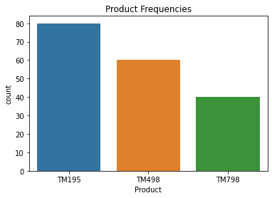

```python
# Countplot of product id's
plt.title("Product Frequencies")
sns.countplot(data = data, x = "Product");
```

The most common treadmill was TM195.  
The least common treadmill was TM798.

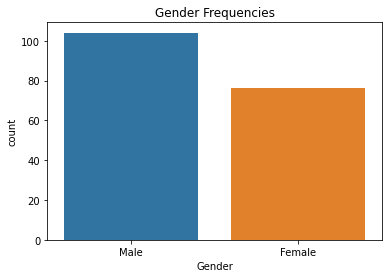

```python
# Countplot of gender
plt.title("Gender Frequencies")
sns.countplot(data = data, x = "Gender");
```

There were more males than females in this dataset.

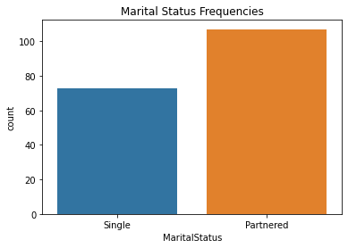

```python
# Countplot of marital status
plt.title("Marital Status Frequencies")
sns.countplot(data = data, x = "MaritalStatus");
```

There were more partnered people than single people in this dataset.

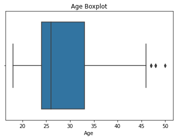

```python
# Boxplot of age
plt.title("Age Boxplot")
sns.boxplot(data = data, x = "Age");
```

The median age was around 26.  
50% of poeple in the data were between ages 24-34.  
There were some outliers who were aged over 46.

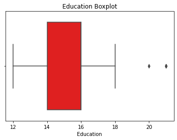

```python
# Boxplot of years of education
plt.title("Education Boxplot")
sns.boxplot(data = data, x = "Education", color = "red");
```

50% of people had between 14 and 16 years of education.  
Some people were considered outliers with over 18 years of education.  
Everyone in this dataset had atleast 12 years of education.

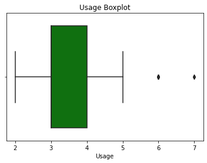

```python
# Boxplot of treadmill usage
plt.title("Usage Boxplot")
sns.boxplot(data = data, x = "Usage", color = "green");
```

50% of people wanted to use the treadmill 3-4 times per week.  
Some people were outliers who wanted to use the treadmill over 5 times per week.  
Everyone in the dataset wanted to use the treadmill at least 2 times per week.

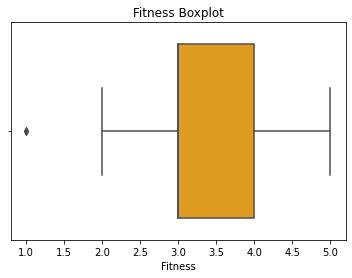

```python
# Boxplot of fitness level
plt.title("Fitness Boxplot")
sns.boxplot(data = data, x = "Fitness", color = "orange");
```

Some people were outliers who thought ther were very unfit and rated their fitness under 2.  
50% of people rated their fitness between 3 and 4.

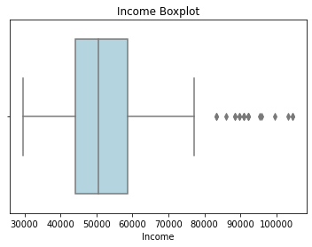

```python
# Boxplot of income
plt.title("Income Boxplot")
sns.boxplot(data = data, x = "Income", color = "lightblue");
```

Some people were outliers with high incomes of over 76000.  
75% of people had incomes of less than 59000.

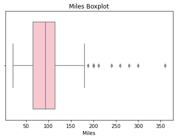

```python
# Boxplot of expected treadmill miles
plt.title("Miles Boxplot")
sns.boxplot(data = data, x = "Miles", color = "pink");
```

50% of people expected to run between 66 and 115 miles.  
Some people expected to run very large distances of over 180 miles.

## Multivariate Analysis

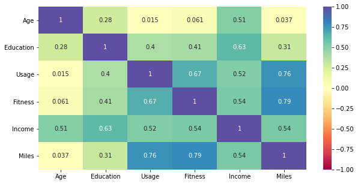

```python
# heatmap of features, displays correlation between each pair of features
plt.figure(figsize=(10,5))
sns.heatmap(data.corr(), annot = True, cmap = 'Spectral', vmin = -1, vmax = 1)
plt.show()
```

There is a strong positive correlation of miles with usage and miles with fitness.  
There is a positive correlation of income and all other variables.

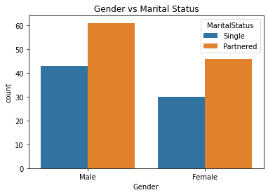

```python
# gender vs marital status
plt.title("Gender vs Marital Status")
sns.countplot(data = data, x = "Gender", hue = "MaritalStatus");
```

The least common group of customers are single females.  
The most common group of customers is partnered males.

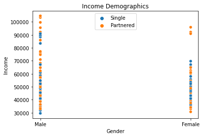

```python
# income by gender and marital status
plt.title("Income Demographics")
sns.scatterplot(data = data, x = "Gender", y = "Income", hue = "MaritalStatus", ci = False)
plt.legend(loc = "upper center")
plt.show()
```

There are more males in the highest income groups.  
There are mostly partnered people in the high income groups.  
The low income groups are mixed among all demographics.

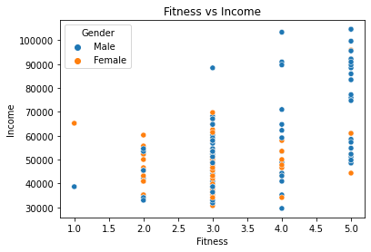

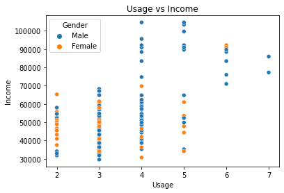

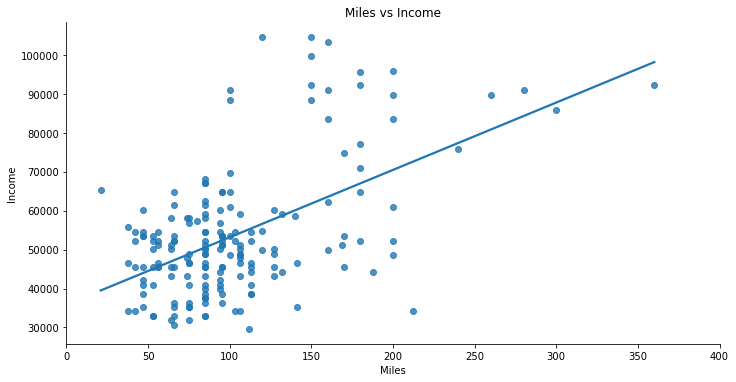

```python
# scatterplots of fitness, usage, and miles with income
plt.title("Fitness vs Income")
sns.scatterplot(data = data, x = "Fitness", y = "Income", hue = "Gender")
plt.show()

plt.title("Usage vs Income")
sns.scatterplot(data = data, x = "Usage", y = "Income", hue = "Gender")
plt.show()

sns.lmplot(data = data, x = "Miles", y = "Income", height = 5, aspect = 2, ci = False)
plt.xlim(0, 400)
plt.title("Miles vs Income")
plt.show()
```

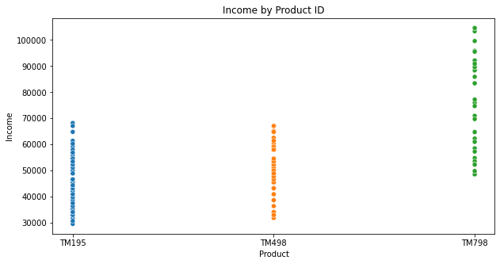

```python
# product id by income
plt.figure(figsize=(10,5))
plt.title("Income by Product ID")
sns.scatterplot(data = data, x = "Product", y = "Income", hue = "Product")
plt.legend('',frameon = False)
plt.show()
```

Although the TM195 is the most popular treadmill overall, the TM 798 is the most popular among high income users.  
The TM195 and TM498 are bough by people similar income groups.

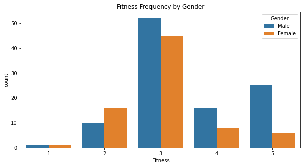

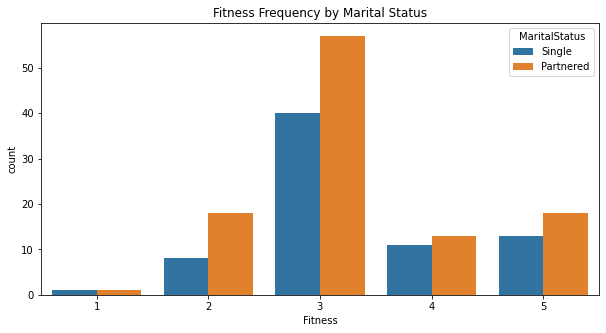

```python
# fitness counts by gender
plt.figure(figsize=(10,5))
plt.title("Fitness Frequency by Gender")
sns.countplot(data = data, hue = "Gender", x = "Fitness")
plt.show()

# fitness counts by marital status
plt.figure(figsize=(10,5))
plt.title("Fitness Frequency by Marital Status")
sns.countplot(data = data, hue = "MaritalStatus", x = "Fitness")
plt.show()
```

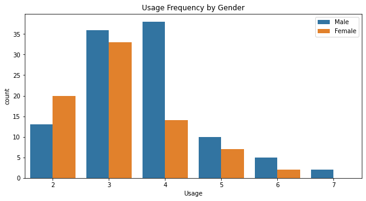

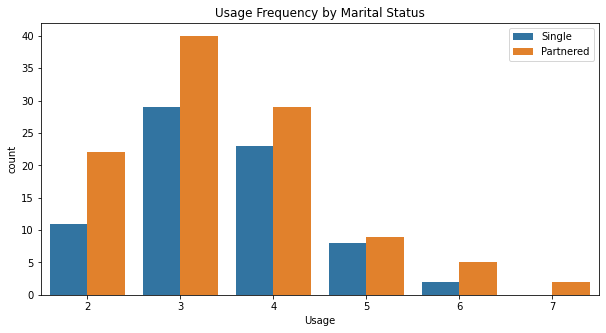

```python
# usage counts by gender
plt.figure(figsize=(10,5))
plt.title("Usage Frequency by Gender")
sns.countplot(data = data, hue = "Gender", x = "Usage")
plt.legend(loc = "upper right")
plt.show()

# usage counts by marital status
plt.figure(figsize=(10,5))
plt.title("Usage Frequency by Marital Status")
sns.countplot(data = data, hue = "MaritalStatus", x = "Usage")
plt.legend(loc = "upper right")
plt.show()
```

More males had expected usage in all categories except 2 times per week.  
More partnered people in all usage categories.  
Big drop off in expected usage of more than 4 times per week regarless of gender or marital status.

```python
# creates bins for miles variable
data['Miles_bins'] = pd.cut(data['Miles'], bins = [0, 100, 200, 300, 400], right = False)
```

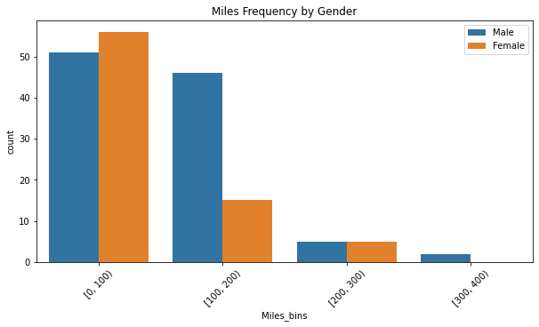

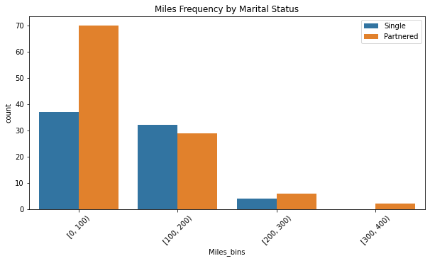

```python
# miles counts by gender
plt.figure(figsize=(10,5))
plt.title("Miles Frequency by Gender")
sns.countplot(data = data, hue = "Gender", x = "Miles_bins")
plt.xticks(rotation = 45)
plt.legend(loc = "upper right")
plt.show()

# miles counts by marital status
plt.figure(figsize=(10,5))
plt.title("Miles Frequency by Marital Status")
sns.countplot(data = data, hue = "MaritalStatus", x = "Miles_bins")
plt.xticks(rotation = 45)
plt.legend(loc = "upper right")
plt.show()
```

Vast majority of users expected to run less than 200 miles regardless of other demographics.  
Slightly more females expected to run between 0 and 100 miles, while about 3 times as many males expected to run between 100 and 200 miles.  
Only partnered males expected to run over 300 miles.  
About twice as many partnered people expected to run between 0 to 100 miles as single people.

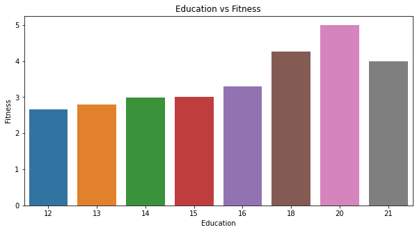

```python
# barplot of education and fitness
plt.figure(figsize=(10,5))
plt.title("Education vs Fitness")
sns.barplot(data = data, x = "Education", y = "Fitness", ci = False);
```

Perceived fitness increases with education until 21 years of education, where it drops slightly.

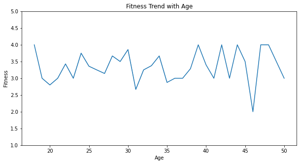

```python
# trend in fitness as age increases
plt.figure(figsize=(10,5))
plt.ylim(1, 5)
plt.title("Fitness Trend with Age")
sns.lineplot(data = data, x = "Age", y = "Fitness", ci = False);
```

Perceived fitness was relatively constant around 3-4 for all ages.  
There were some slight dips in perceived fitness, the most notable for 46 year olds.

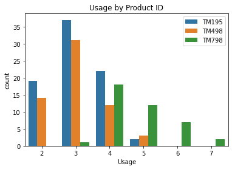

```python
# Usage by product id
plt.title("Usage by Product ID")
sns.countplot(data = data, x = "Usage", hue = "Product")
plt.legend(loc = "upper right")
plt.show()
```

The high usage categories were dominated by the TM798 model treadmill.  
Low usage categories were mostly the TM195 and TM498, but the TM195 was more common.  
Those two models did not have any expected usage of over 5 times per week.

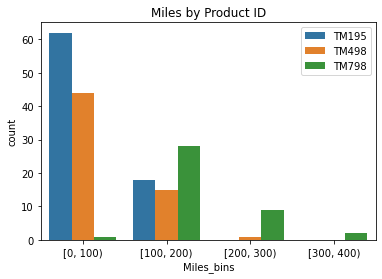

```python
# Miles by product id
plt.title("Miles by Product ID")
sns.countplot(data = data, x = "Miles_bins", hue = "Product")
plt.legend(loc = "upper right")
plt.show()
```

The TM195 is most popular for 0-100 miles.  
The TM195 and TM498 ar similarly popular for 100-200 miles, but the TM798 is most popular in this range.

## Insights and Reccomendations

Customer Profile:

- There are more male customers than females and more partnered customers than single.
- There are more partnered people in high income categories.
- The TM195 is the most common treadmill overall.
- The TM195 and TM498 were mostly used by low to middle income users and was associated with lower usage.
- The TM798 was most popular among high income users and was associated with high usage.
- Wealthier people tend to have higher perceived fitness and higher expected treadmill miles.
- Perceived fitness tends to be pretty constant regarless of age, but increases with education.